# Gastos mensuales de un estudiante universitario

[figure not shown]

### **Introducción**

Relevancia: Conocer los diferentes gastos que un alumno universitario tiene al mes e identificar el monto total que emplea el estudiante al mes. Planificación:

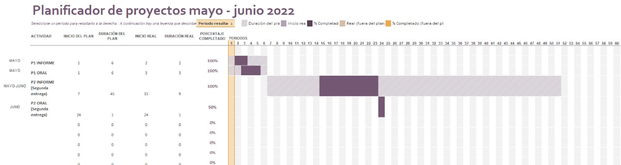

### **Datos**

Recolección de datos:

Proceso de recolección de datos: Primero se realizó una encuesta con 28 variables. Para que tenga más acogida se utilizó un sorteo a una discoteca “Valetodo Downtown” La encuesta se mandó por vía correo electrónico, whatsapp y presencial. Se utilizaron esos medios porque eran los más accesibles para nosotros, pues no sabíamos por qué medios más encuestar. Puesto que, no se lograba completar la muestra requerida, se optó por realizar la encuesta de uno en uno en los pasillos de UTEC. Se trató de llegar a la población por medio de nuestros conocidos y amigos. Finalmente se logró completar 204 observaciones.

Población, muestra y muestreo:

La población a estudiar es la comunidad educativa UTEC. Se tomó una muestra de 204 estudiantes, se trató de hacerla lo más representativa posible, considerando si los estudiantes son becados o no, la escala de pago, la carrera y el ciclo. Pero, por motivos de tiempo se utilizó un muestreo por conveniencia, pues, no teníamos el alcance a todos los estudiantes. Esto consistió en enviar las encuestas a las personas cercanas a nosotros, conocidos de conocidos y por último la vía presencial en los pasillos de la UTEC.

### **VARIABLES:**

| VARIABLE | TIPO DE VARIABLE | RESTRICCIONES |
| --- | --- | --- |
| Alquiler | variable numérica, discreta | Números enteros no negativos en soles. |
| Gastos en pasaje | variable numérica, discreta | Números enteros no negativos en soles. |
| Gastos en la alimentación | variable numérica, discreta | Números enteros no negativos en soles. |
| Pago del Servicio de Agua | variable numérica, continua | Números no negativos. en soles. |
| Pago del Servicio de Luz | variable numérica, continua | Números no negativos. en soles. |
| Pago del Servicio de Gas Natural | variable numérica, continua | Números no negativos. en soles. |
| Mensualidad de la universidad | variable numérica, discreta | Números enteros no negativos en soles. |
| Materiales de estudio | variable numérica, discreta | Números enteros no negativos en soles. |
| Gastos en vestimenta | variable numérica, discreta | Números enteros no negativos en soles. |
| Gastos en cursos extracurriculares | variable numérica, discreta | Números enteros no negativos en soles. |
| Gastos en salidas | variable numérica, discreta | Números enteros no negativos en soles. |
| Gastos en aseo personal | variable numérica, discreta | Números enteros no negativos en soles. |
| Gastos extras | variable numérica, discreta | Números enteros no negativos en soles. |
| Créditos matriculados | variable numérica, discreta | Números enteros en soles desde 1 a 26 |
| Carrera | variable categórica, nominal | Carreras disponibles en la universidad UTEC |
| Ciclo | variable categórica, ordinal | Números enteros desde 1 a 10 |
| Becado | variable categórica, nominal | Tiene dos opciones: Si y No |
| Escala | variable categórica, nominal | Letras desde A a E |
| Residencia | variable categórica, nominal | Tiene dos opciones: Vivienda alquilada y Vivienda propia |
| Transporte | variable categórica, nominal | Tiene tres opciones: A pie, Bus y Vehículo propio |

### **Limpieza de base de datos**

En nuestra base de datos llamada Formulario.csv se usó los criterios de decisión

- Al comienzo de nuestra encuesta observamos valores erróneos (alejados de la realidad); entonces reconsultamos la fuente a los entrevistados para garantizar un mejor resultado.
- Todos los valores numéricos de los gastos fueron restringidos con números enteros para evitar tener datos sucios numéricos.
- Restringimos todas las respuestas como obligatorio para no tener datos vacíos.
- Eliminamos las tres primeras columnas de las variables: marca temporal, correo y nombres.
- Cambiamos de nombre a todas nuestras variables por nombres cortos para facilitar las interpretaciones en las gráficas.
- Obtuvimos una base de datos limpia que posteriormente nos facilitará en el análisis de los datos.

#### **Proceso de limpieza de datos**

```r
library(readr)
```

```r
library(ggplot2)
```

```r
library(dplyr)
```

```r
library(cowplot)
```

```r
library(tidyr)
```

```r
library(psych)
```

Leemos las columnas 4 a 29 de nuestra base de datos

```r
Datos <- read_csv("Formulario.csv") %>% select(4:29)
```

Realizamos el cambio de nombre a las variables (El M y S antes de cada una es por mensual y semanal).

Incluimos una variable adicional a nuestra base de datos

- Total_gasto : Representa el gasto mensual de un estudiante.

```r
Total_gasto_ <- Datos %>% select(M_Alquiler:M_Luz,M_gasN:Gastos_extras,M_Plataformas_serv,M_Cursos_extracurriculares,Mensualidad_univ,M_Gasolina,Pasaje) %>% rowSums()

Datos <- Datos %>% mutate(Total_gasto = Total_gasto_+3*S_Alimentacion)
```

## Descriptores Numéricos

Resumen de los principales gastos. Se han eliminado todos los ceros de la muestra para el resumen

```
##                      mean         sd  median   min     max
## S_Alimentacion  205.92157  220.07052  125.00  25.0 1000.00
## M_Agua           68.16275   48.45671   50.60   9.9  220.20
## M_Luz           100.77647   87.58260   70.00  10.0  438.00
## M_Internte       89.80392   51.13591  100.00  20.0  300.00
## M_estudio_mat    66.64706   76.55817   40.00   4.0  400.00
## M_Salud         101.15686   80.37696  100.00  10.0  300.00
## M_AseoPersonal   64.80392   47.63361   50.00  10.0  200.00
## Gastos_extras   112.84314  103.77020   90.00  10.0  500.00
## M_Presupuesto  1425.52941  831.22525 1260.00 430.0 4000.00
## Total_gasto    2501.30686 1552.71733 2221.09 541.5 8560.66
```

## Alumnos por ciclo

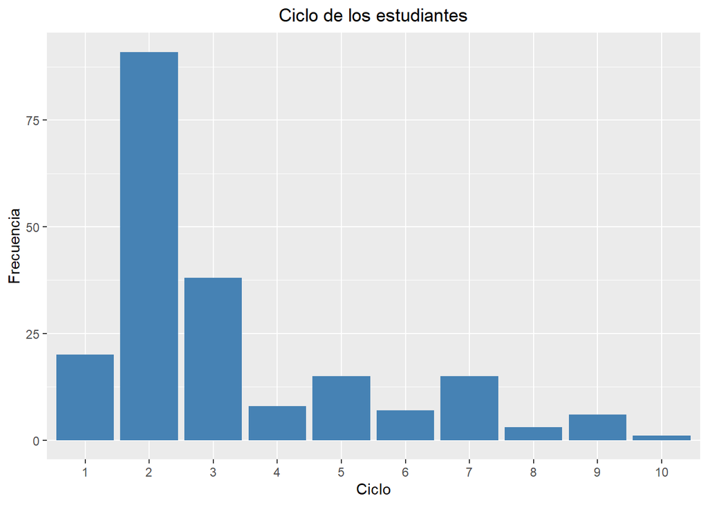

```
## [1] 91
```

```
## [1] 44.60784
```

La mayoría de alumnos encuestados se encuentra en el 2do ciclo, con un total de 91 alumnos que representan el 45% del total de encuestados.

## Alumnos por carrera

Se muestra la cantidad de alumnos por carrera que fueron encuestados.

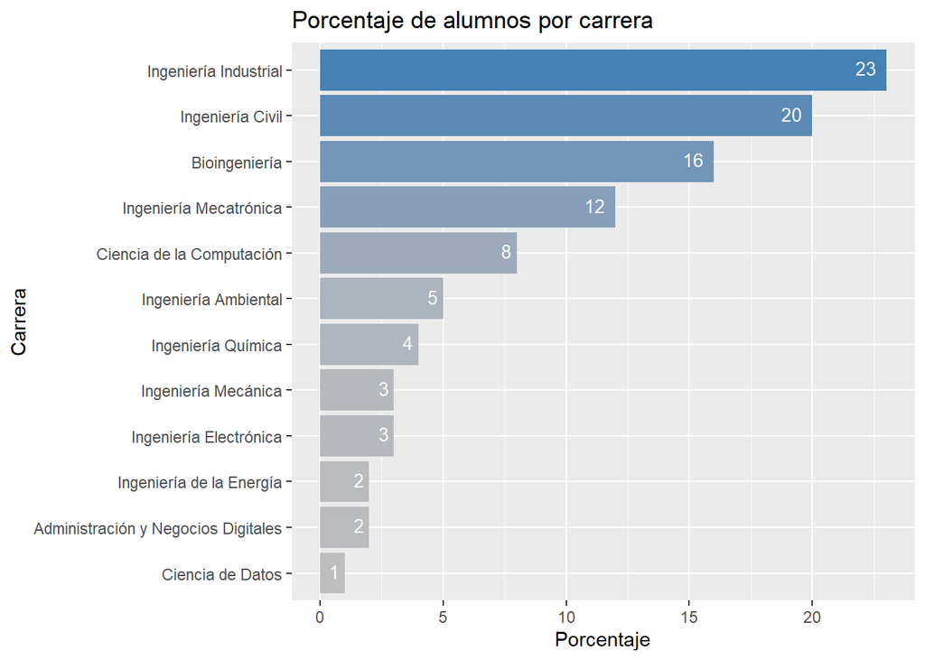

Los alumnos de Ingeniería Industrial fueron los más consultados, en cuanto a los menos consultados fueron de Administración y Negocios Digitales y Ciencia de Datos. Es coherente dado que la carrera de Ingeniería Industrial tiene la mayor cantidad de alumnado en la universidad y en cuanto a las otras mencionadas son carreras que iniciaron recién en el periodo 2021-1.

## Cantidad de becados

```r
Datos %>% group_by(Becado) %>% summarize(Frecuencia =length(Becado)) %>%
          mutate(Porcentaje=round(Frecuencia/sum(Frecuencia),2)) %>% arrange(desc(Frecuencia))
```

```
## # A tibble: 2 x 3
##   Becado Frecuencia Porcentaje
##   <chr>       <int>      <dbl>
## 1 Si            119       0.58
## 2 No             85       0.42
```

Hay 119 alumnos becados y 85 no becados que fueron encuestados.

## Créditos matriculados

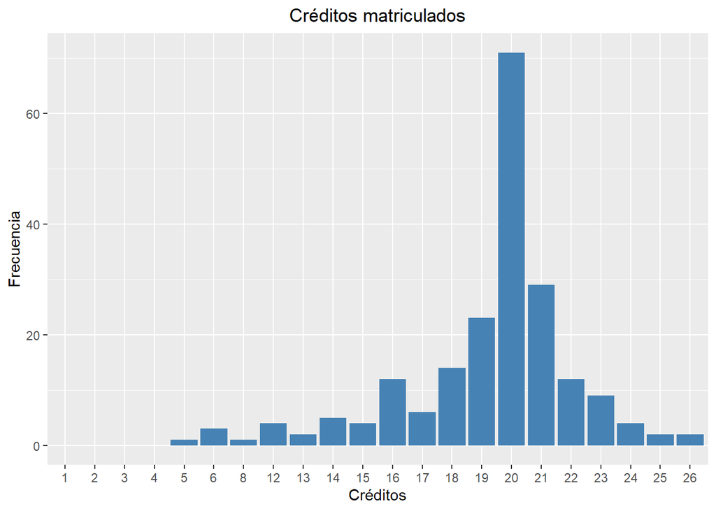

La mayoría de alumnos lleva 20 créditos en un ciclo. La gráfica tiene la forma de una distribución normal.

## Presupuesto

En el caso del presupuesto, se ha filtrado un alumno que tiene un presupuesto muy alto. Esto se hace para que se obtenga una mejor gráfica

```
## [1] 90272
```

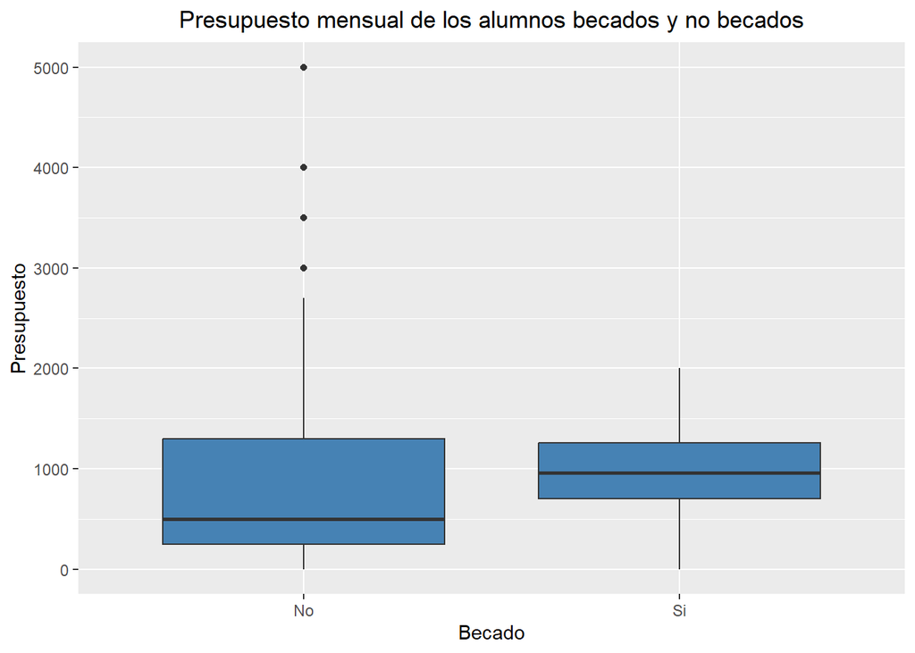

Observamos que los alumnos becados tienen una menor dispersión en los datos en comparación a los no becados. La mediana del presupuesto de los alumnos becados es mayor al de los alumnos no becados. Esto puede deberse porque los estudiantes becados reciben una mensualidad fija de parte del Estado. Los alumnos no becados registran valores atípicos.

## Gasto mensual del alumno

Para hacer una comparación más justa, al gasto total mensual le quitaremos el gasto por mensualidad y el gasto de alquiler.

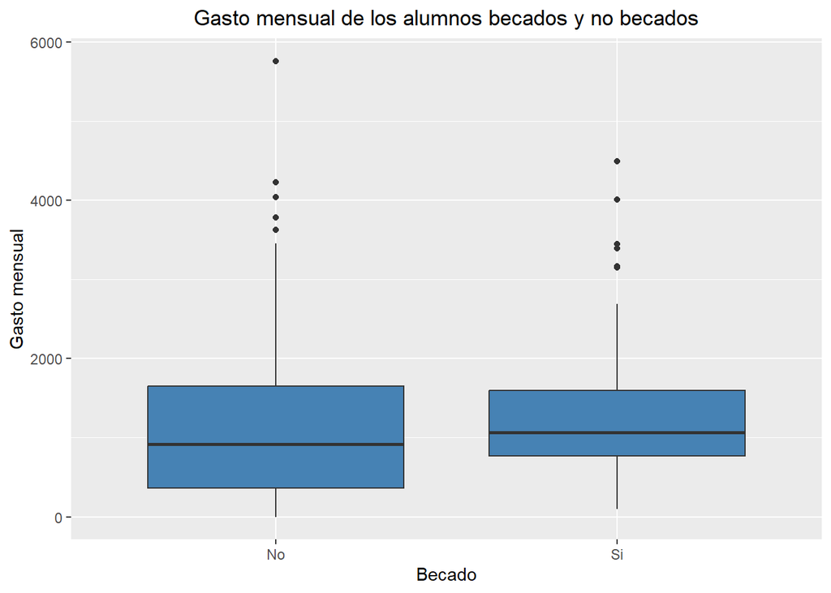

## Gasto de Luz

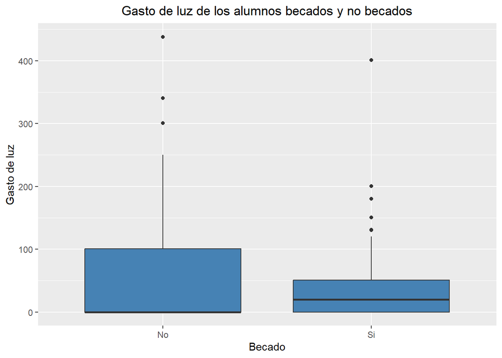

La mediana del gasto de luz de los alumnos no becados es de 0. Eso indica que muchos estudiantes no consideraron ese gasto en su presupuesto. En el caso de los estudiantes becados la mediana es mayor. La dispersion de datos es menor en el caso de los estudiantes becados.

## Gasto de gas natural

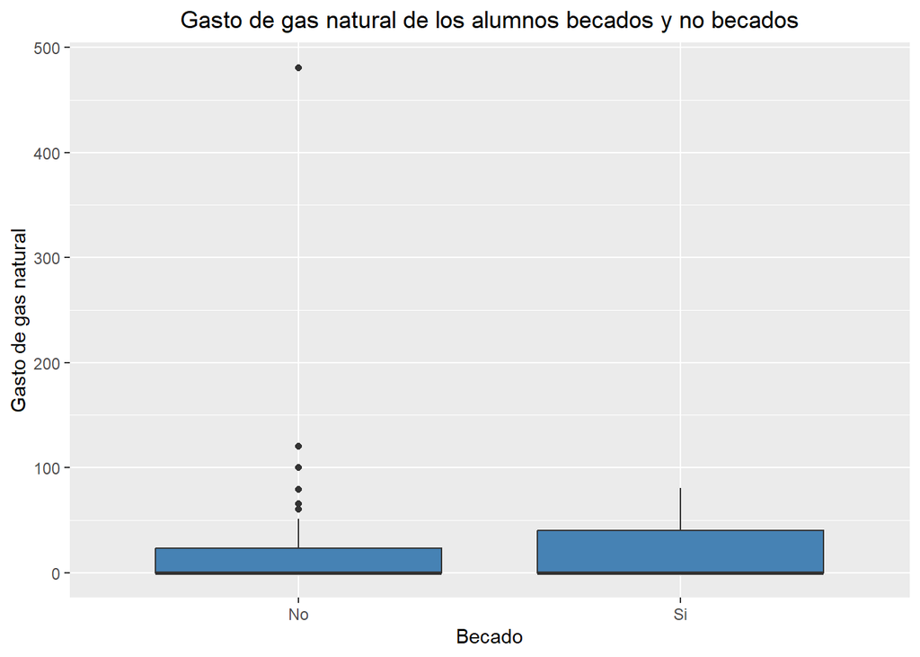

En ambos grupos de estudiantes la mediana de los datos es 0. Indica que la mayoría de estudiantes no cosideraron este gasto en su presupuesto. Los alumnos no becados tienen varios valores atípicos.

## Gasto de agua

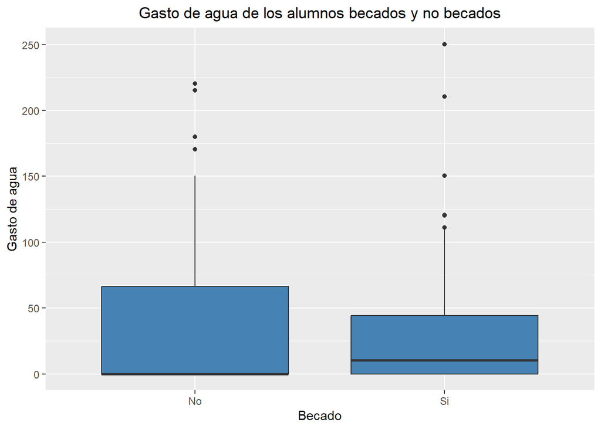

El 50% a más de los estudiantes de los estudiantes no becados no han considerado el gasto de agua en su presupuesto. Los datos de los alumnos becados están menos dispersos. Ambos presentan valores atípicos.

## Gasto de alimentación

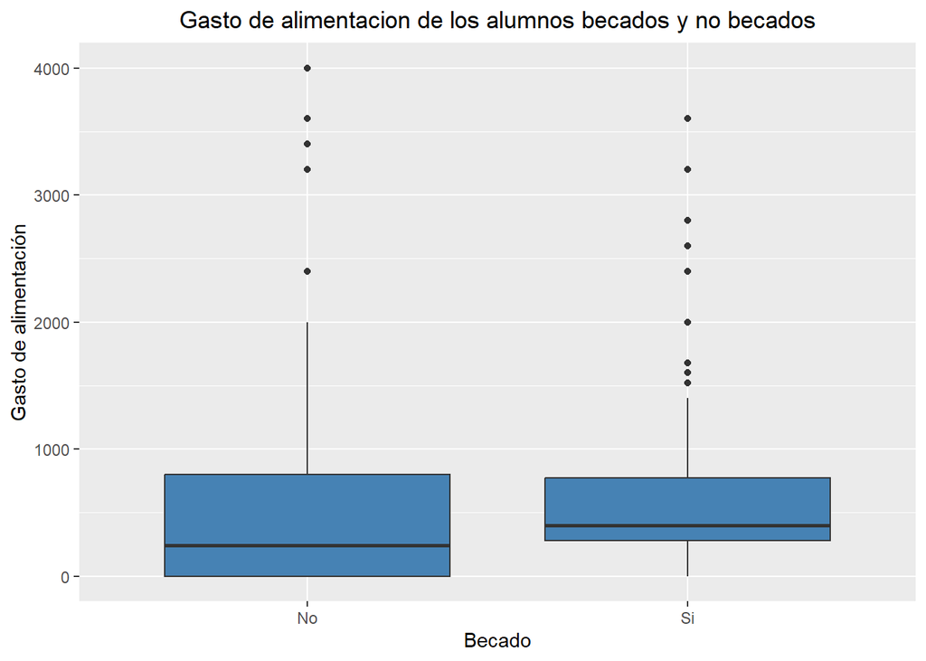

Existe mayor dispersión de datos en el caso de alumnos no becados. En ambos hay valores atípicos. La mediana de los gastos de alimentación de alumnos becados es mayor al de los no becados.

## Gasto de Internet

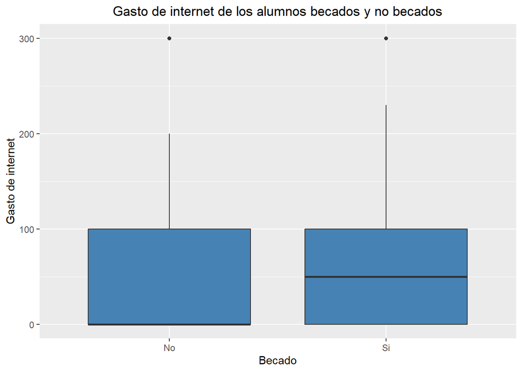

Así como en casos anteriores, la mediana de los datos de los alumnos no becados es 0. Varios no han considerado los gastos de internet en su presupuesto. Ambos gráficos presentan datos dispersos.

## Gasto en balón de gas

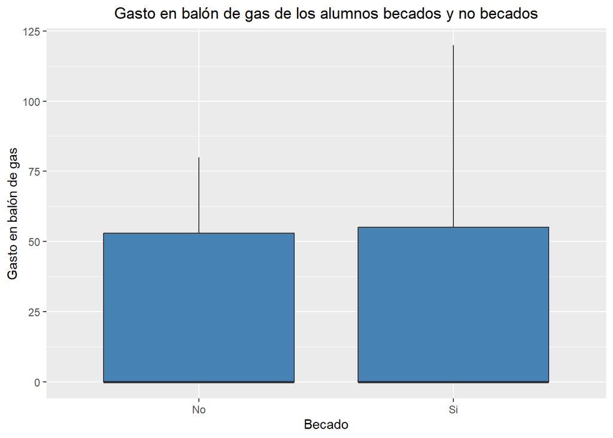

La mediana de los datos de ambos grupos es de 0. Más del 50% de los estudiantes no han considerado los gastos de balón de gas en su presupuesto. Ambos gráficos presentan datos dispersos.

## Gasto de materiales

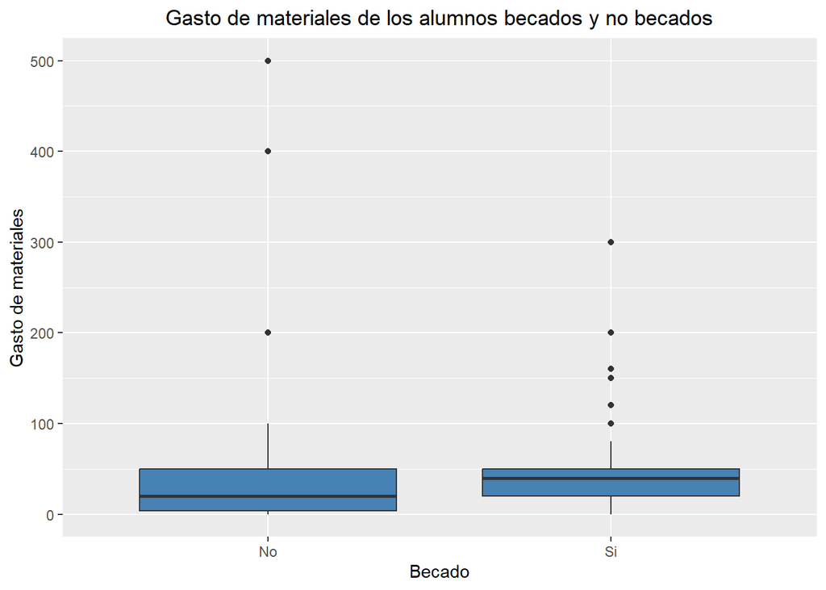

La dispersión de datos en ambos grupos es baja. La mediana de los gastos de materiales en los alumnos becados es mayor a la del grupo de no becados. Se presentan datos atípicos en los dos grupos.

## Gastos de Salud

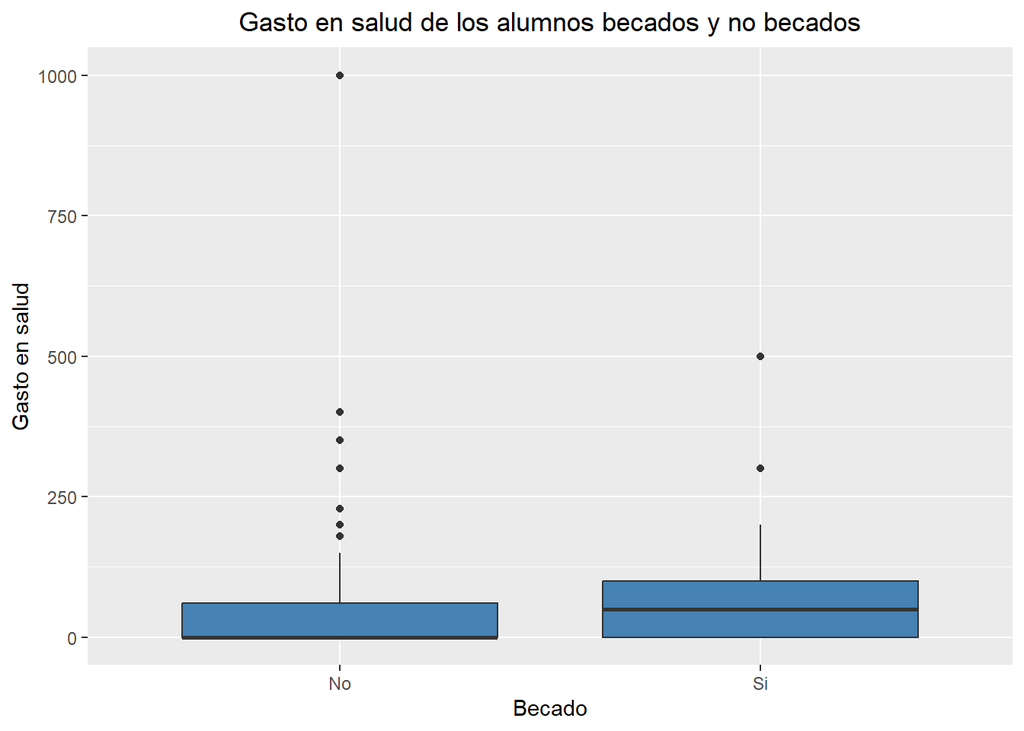

El 50% a más de los estudiantes no becados no han considerado gasto de salud en su presupuesto. Se presentan datos atípicos en los dos grupos.

## Gastos de Aseo Personal

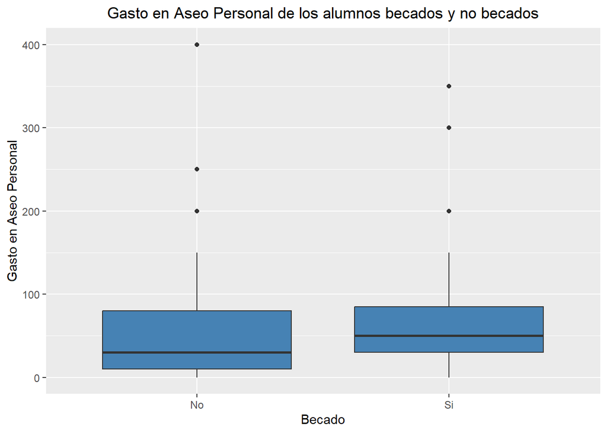

Los alumnos becados tienen una mediana mayor en gastos de aseo personal en comparación a los no becados. Además que presentan menor dispersión de los datos. Ambos grupos tienen valores atípicos.

## Gastos extras

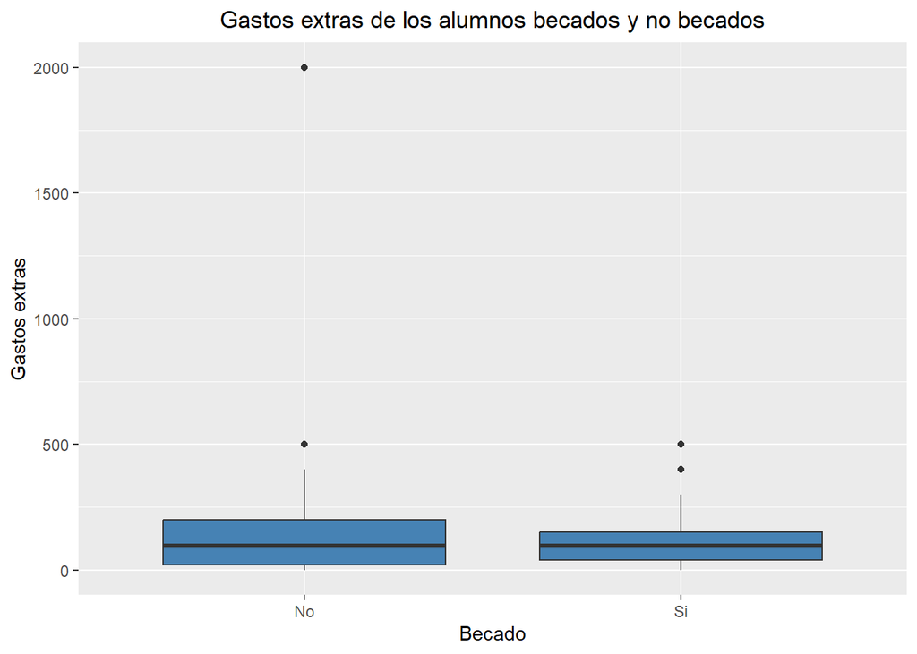

Ambos grupos presentan poca dispersión de datos. La mediana de ambos grupos es similar en los gastos extras. Presentan pocos valores atípicos.

## Comparación de los tipos de gastos

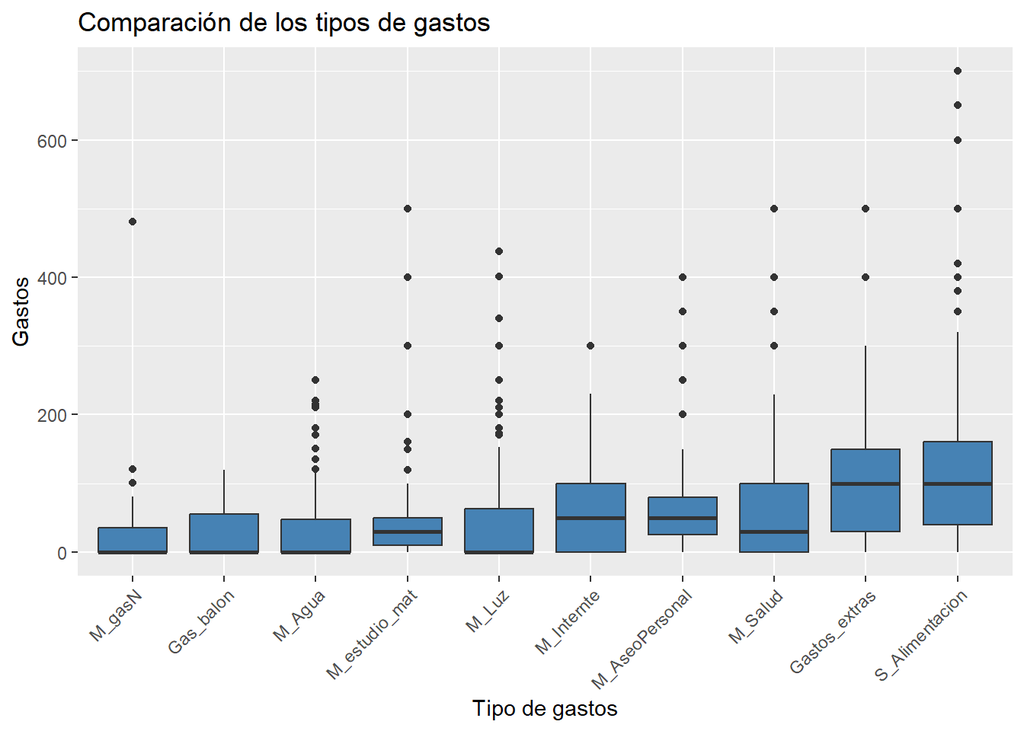

```r
prueba <- gather(data = Datos, key = "tipo", value = "cantidad", c(6:8,10:16))
prueba %>%  filter(cantidad < 750) %>% ggplot(aes(x=reorder(tipo,cantidad),y=cantidad))+
            geom_boxplot(fill="steelblue")+
            labs(title = "Comparación de los tipos de gastos",
                    x="Tipo de gastos",y="Gastos")+
          theme(axis.text.x = element_text(angle = 45, hjust = 1),
                legend.position = "none")
```

Hacemos una comparación de los diferentes tipos de gastos

## Gastos de Agua y Luz

Realizamos una comparación entre los datos de agua y luz y veremos como se comportan. Eliminaremos los datos de luz y agua que sean de 0.

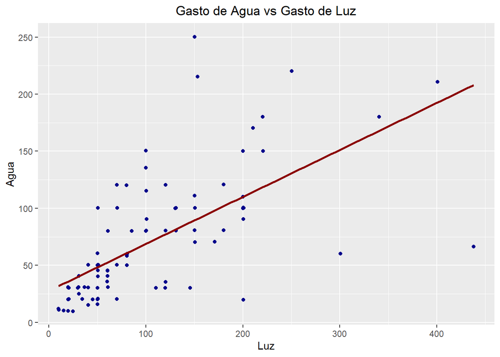

En la gráfica la linea roja es la recta de regresión que se ajusta a los datos, este se realiza utilizando geom_smooth porque dentro de sus parámetros se encuentra el parámetro method = lm (linear model).

Hallamos la correlación entre las variables

```r
cor(Datos$M_Agua,Datos$M_Luz,use='complete.obs')
```

```
## [1] 0.7698791
```

La correlación es de 0.77. Lo que significa que las variables están fuertemente correlacionadas positivamente.

## Gastos de salud y aseo personal

Realizamos una comparación entre los datos de salud y aseo personal y veremos como se comportan. Eliminaremos los datos de salud y de aseo personal que sean 0.

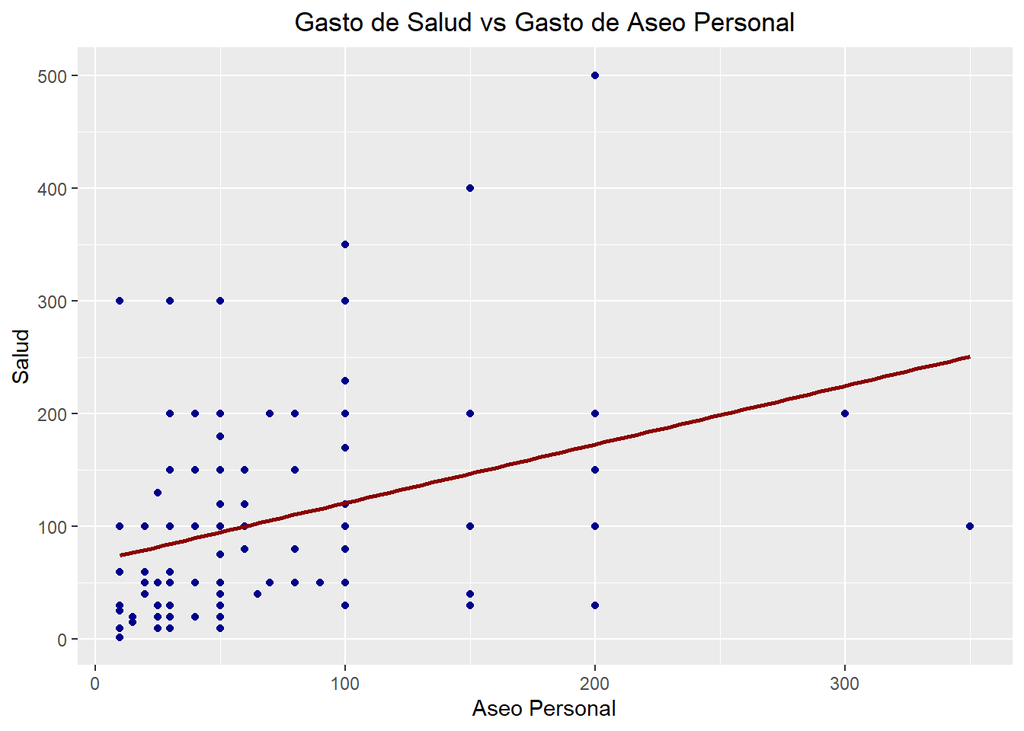

Hallamos la correlación entre las variables

```r
cor(Datos$M_AseoPersonal,Datos$M_Salud,use='complete.obs')
```

```
## [1] 0.1963317
```

La correlación es de 0.2. Lo que significa que las variables tienen una correlación positiva baja. No hay una dependencia lineal entre las variables.

## Carrera

Quisieramos analizar la carrera de la muestra de estudiantes. En particular escogeremos como caso a los estudiantes de Ingeniería Industrial ya que son mayoría en nuestra muestra.

El experimento que proponemos es el siguiente: Examinar el número de intentos hasta que encontremos al primer estudiante que se encuentre en la carrera de Ingeniería Industrial

De acuerdo a nuestro experimento entonces utilizaremos una distribución geométrica.

Disponemos de 47 estudiantes de Ingeniería Industrial de un total de 204 estudiantes.

El espacio muestral es: Espacio = {“Estudiante de Industrial”,“Otra carrera”}

Tenemos las siguientes consideraciones:

- Estudiante de Industrial como caso de éxito.
- Otra carrera como caso de no éxito.

```r
##Probabilidad de Exito
p_exito <- sum(Datos$Carrera == "Ingeniería Industrial")/nrow(Datos)
p_exito
```

```
## [1] 0.2303922
```

Variable Aleatoria X = Número de intentos hasta encontrar el primer estudiante de Ingeniería Industrial

$$X \sim Geom(0.23)$$
Veremos las gráficas de función de masa en la distribución geométrica y de distribución acumulada.

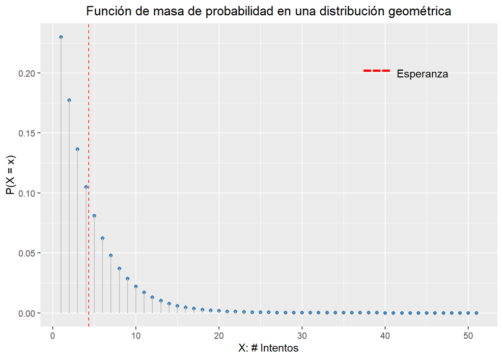

```r
data_geom <- data.frame(first = dgeom(0:50,0.23),second = 1:51)
data_geom %>% ggplot(aes(x=second,y=first))+
geom_point(color="steelblue")+
geom_segment( aes(x=second, xend=second, y=0, yend=first), color="grey")+
geom_vline(xintercept = 1/p_exito,linetype="dashed",color="red")+
labs(title="Función de masa de probabilidad en una distribución geométrica",x="X: # Intentos",y="P(X = x)")+
theme(plot.title = element_text(hjust = 0.5))+
annotate("text", x = 44.5, y = 0.2, label = "Esperanza")+
annotate("text", x = 39, y = 0.205, label = "---",color="Red",size=10)
```

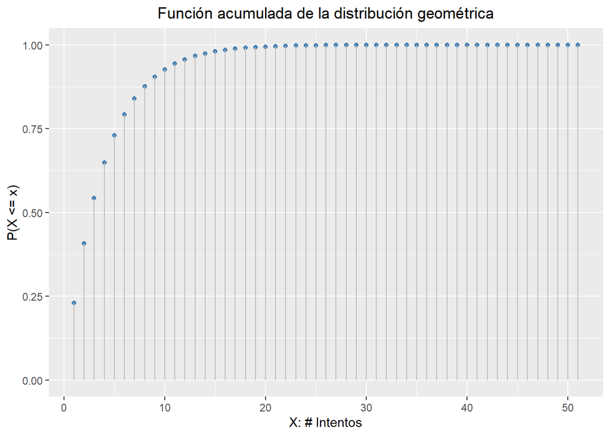

```r
data_geom <- data.frame(first = pgeom(0:50,0.23),second = 1:51)
data_geom %>% ggplot(aes(x=second,y=first))+
geom_point(color="steelblue")+
geom_segment( aes(x=second, xend=second, y=0, yend=first), color="grey")+
labs(title="Función acumulada de la distribución geométrica",x="X: # Intentos",y="P(X <= x)")+
theme(plot.title = element_text(hjust = 0.5))
```

Valor esperado

```r
round(1/p_exito,2)
```

```
## [1] 4.34
```

#### Casos de cálculo

¿Cuál es la probabilidad de hallar el primer estudiante de Ingenieria Industrial después de 10 intentos o más ? (P(X > 9)) = 1 - P(X <= 9)

```r
1-pgeom(9-1, 0.23)
```

```
## [1] 0.09515169
```

La probabilidad es de un 9.5%

¿Cuál es la probabilidad de hallar el primer estudiante de Ingenieria Industrial a lo más en 5 intentos ? (P(X <= 5))

```r
pgeom(5-1, 0.23)
```

```
## [1] 0.7293216
```

La probabilidad es de un 73%.

## Gasto de Alquiler

Quisieramos analizar el gasto de alquiler de los estudiantes. Para ello vamos a reducir nuestra base de datos y consideraremos solo a aquellos estudiantes que viven en una vivienda alquilada.

```r
Datos_2 <- Datos %>% filter(Residencia == "Vivienda alquilada")
```

Crearemos una variable adicional llamado Precio, esta será una variable categórica, la cual tendrá dos valores: Mayor a 1000 y 1000 o menos. De acuerdo a nuestro criterio.

- Mayor: Costo de alquiler mayor a 1000 soles.
- Menor: Costo de alquiler menor o igual a 1000 soles.

```r
Datos_2$Precio <- ifelse(Datos_2$M_Alquiler>1000,"Mayor","Menor")
```

Vemos los resultados

```r
table(Datos_2$Precio)
```

```
##
## Mayor Menor
##    11    76
```

Nuestra consulta es ¿Cuál es la probabilidad que “x” Estudiantes alquilen una vivienda a un precio menor a 1000 soles de la muestra de 87 estudiantes? Dada esta consulta utilizaremos una distribución binomial.

El espacio muestral es: Espacio = {“Alumno que alquile una vivienda a un precio de 1000 soles o menos”,“Alumno que alquile una vivienda a precio mayor a 1000 soles”}

Realizamos las siguientes consideraciones:

- Alumno que alquile una vivienda a un precio de 1000 soles o menos como caso de éxito.
- Alumno que alquile una vivienda a precio mayor de 1000 soles como caso de no éxito.

```r
nrow(Datos_2)
```

```
## [1] 87
```

```r
c_e <- sum(Datos_2$Precio == "Menor")/nrow(Datos_2)
##Prob.Exito
c_e
```

```
## [1] 0.8735632
```

```r
c_ne <- sum(Datos_2$Precio == "Mayor")/nrow(Datos_2)
##Prob. No Éxito
c_ne
```

```
## [1] 0.1264368
```

Variable Aleatoria X = Número de estudiantes que alquilan una vivienda a un precio 1000 soles o menos.

$$X \sim Bin(87,0.87)$$
Veremos las gráficas de la función de masa de la distribución binomial y de distribución acumulada

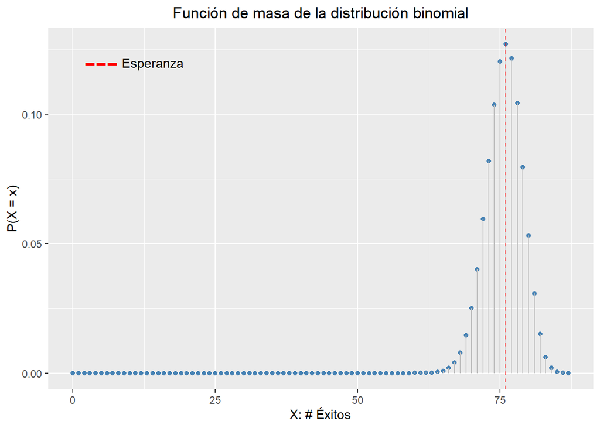

```r
data_binom <- data.frame(first = dbinom(0:87,87,0.87),second = 0:87)
data_binom %>% ggplot(aes(x=second,y=first))+
geom_point(color="steelblue")+
geom_segment( aes(x=second, xend=second, y=0, yend=first), color="grey")+
geom_vline(xintercept = 87*c_e,linetype="dashed",color="red")+
labs(title="Función de masa de la distribución binomial",x="X: # Éxitos",y="P(X = x)")+
theme(plot.title = element_text(hjust = 0.5))+
annotate("text", x = 14, y = 0.12, label = "Esperanza")+
annotate("text", x = 5, y = 0.121, label = "---",color="Red",size=10)
```

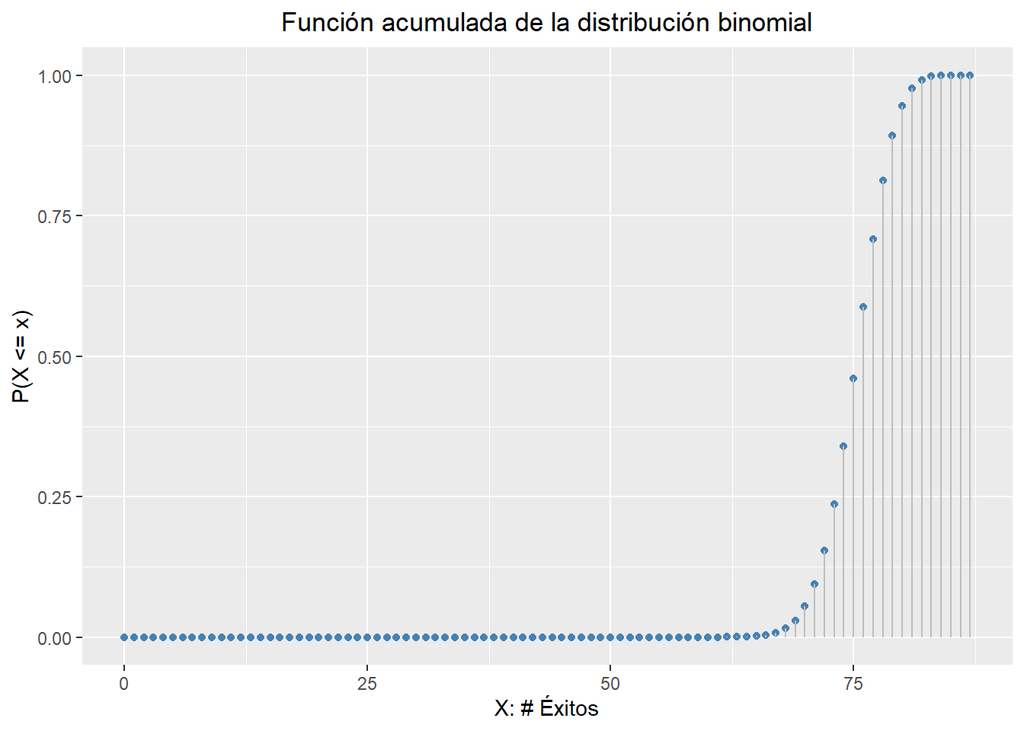

```r
data_binom <- data.frame(first = pbinom(0:87,87,0.87),second = 0:87)
data_binom %>% ggplot(aes(x=second,y=first))+
geom_point(color="steelblue")+
geom_segment( aes(x=second, xend=second, y=0, yend=first), color="grey")+
labs(title="Función acumulada de la distribución binomial",x="X: # Éxitos",y="P(X <= x)")+
theme(plot.title = element_text(hjust = 0.5))
```

Valor esperado

```r
87*c_e
```

```
## [1] 76
```

Luego pasaremos a las Preguntas.

#### Casos de Cálculo

¿Cuál es la probabilidad que más de 75 Estudiantes alquilen una vivienda a un precio de 1000 soles o menos de la muestra de 87 estudiantes? (P(X > 75))

```r
pbinom(75, size=87, prob=0.87, lower.tail = FALSE)
```

```
## [1] 0.5398436
```

```r
pbinom(7, size=87, prob=1-0.87)
```

```
## [1] 0.1075521
```

La probabilidad que 7 estudiantes o menos alquiler una vivienda a un precio mayor a 1000 soles es de 11%

## Gasto mensual total

Analizamos esta variable continua para comprobar si sigue una distribución normal. Primero hallamos la media y la desviación estandar

```r
#Media
mean(Datos$Total_gasto,na.rm=TRUE)
```

```
## [1] 2371.634
```

```r
#Desviacion estandar
sd(Datos$Total_gasto,na.rm=TRUE)
```

```
## [1] 1561.899
```

Elaboramos un gráfico que muestra la función de densidad de la variable

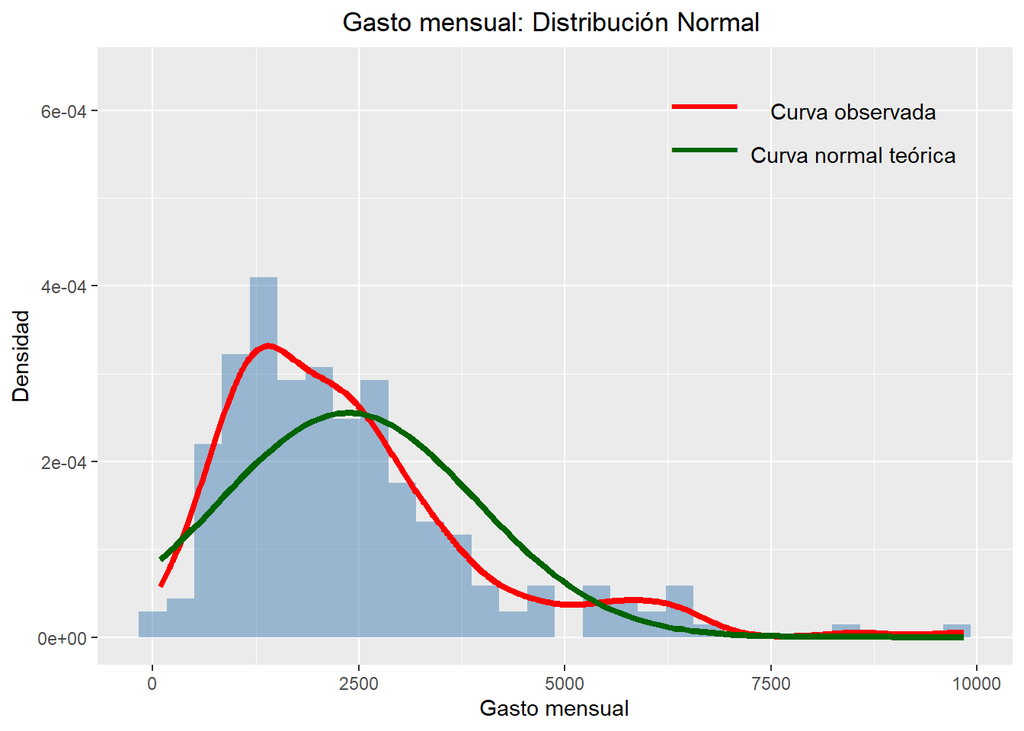

$$f(x) = 0.00026 \times e^{
-\frac{(x-2371.6)^2}{4879063.2}}$$

#### Casos de cálculo

X: Gasto total mensual de un estudiante

Sea X la variable aleatoria que sigue una distribución normal

$$X \sim N(2371.6,1561.9)$$
Proponemos los siguientes casos:

- Probabilidad de que un estudiante tenga un gasto mensual mayor a 3000 soles (P(X > 3000))

```r
pnorm(3000, mean = 2371.6, sd = 1561.9, lower.tail = F)
```

```
## [1] 0.3437204
```

El 34.4% de los alumnos tienen un gasto mayor a 3000 soles.

```r
pnorm(3000, mean = 2371.6, sd = 1561.9) - pnorm(1000, mean = 2371.6, sd = 1561.9)
```

```
## [1] 0.4663515
```

El 46.6% de los alumnos tiene un gasto mensual entre 1000 y 3000 soles.